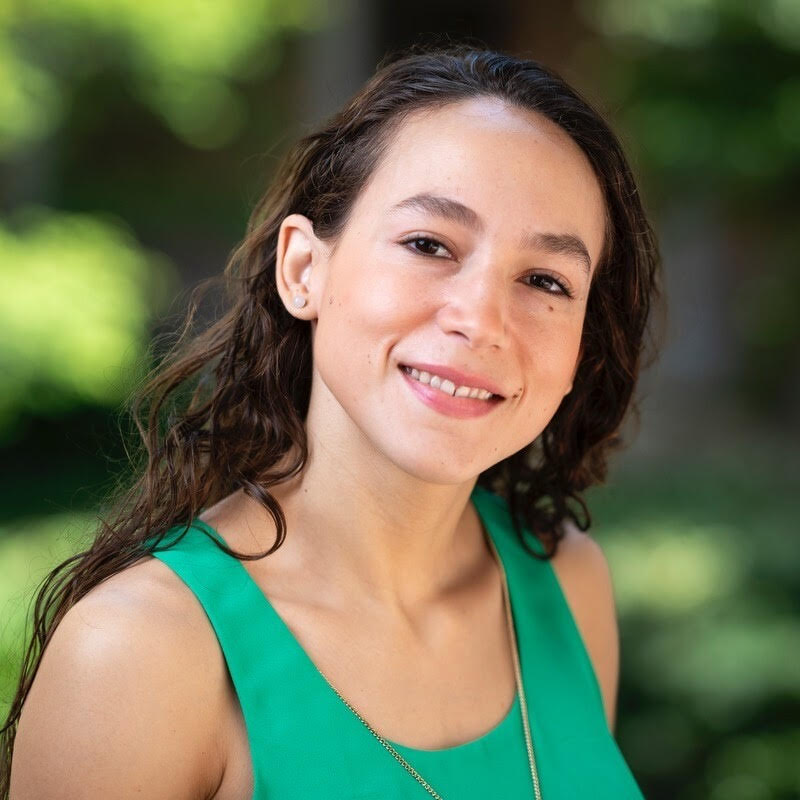

# Alma Plaza-Rodriguez

I am a talented computational biophysicist with a strong background in mathematics and bioinformatics skills. I have a diverse set of modeling and multi-omic bioinformatic analysis skills (7+ years of experience), as well as experimental background in cell and molecular biology, and biochemistry (4+ years of experience).

**My modeling expertise spans:**

Stochastic Reaction-Diffusion simulation, Molecular Modeling, Monte Carlo Simulation, Dynamical Systems Modeling, Development of Deterministic and Stochastic Kinetic Models, Molecular Dynamics, biological physics and mechanics, Finite Element Analysis, Physiological modeling, Protein structure analysis, Systems Biology, Graph-based models, probabilistic modeling, PKPD, QSP

**My Bioinformatics skills span:**

Machine Learning/Deep Learning, Neural Networks with Python and TensorFlow, Clustering Algorithms, PCA, UMAP, tSNE, R, SQL, HPC (High Performance Computing), Statistical Data Analysis, Numpy, SciPy, scikit-learn, pandas, ggpplot, Analysis of bioinformatic and high dimensional data, Mining of biological data, Analysis of -omics data, Git/Github, analysis of Single Cell RNA-Seq data, Bioconductor, spatial transcriptomics analysis, Seurat, Integration of multi-omics data, ATAC-Seq data analysis, Scanpy

**Some of my featured publications are:**

> **Plaza-Rodriguez, Alma I., et al**. “Particle-Based Model of Mechanosensory Contractility Kit Assembly.” Biophysical Journal (2022).

> David Dolgitzer , **Alma Plaza-Rodriguez**, Douglas N. Robinson, Pablo A. Iglesias, et al. “ A continuum model of mechanosensation based on contractility kit assembly”. Biophysical Journal (2024) (co-first author).

> Caglar Cosarderelioglu, Simon Kreimer, **Alma Plaza-Rodriguez**, Pablo Iglesias, Peter Abadir, et al. “Decoding Angiotensin Receptors: TOMAHAQ-based Detection and Quantification of Angiotensin Type I and Type 2 receptors”. Journal of the American Heart Association (2023).

> Caglar Cosarderelioglu, Simion Kreimer, **Alma Plaza-Rodriguez**, Pablo A. Iglesias, Peter Abadir, et al., “Frontal cortex Angiotensin type 2 receptor-interacting protein levels are associated with less amyloid-β burden in postmortem brains of older adults with Alzheimer’s dementia”. Journal of Gerontology: Biological Sciences (2025) (submitted, under review).

**Some of my conference presentations & certifications are:**

> *ICERM Women in Mathematical Biology Workshop Co-Instructor/Lead*, Brown University, January 2025

> *Statistical Analysis of Genome Scale Data Course Certificate*, Cold Spring Harbor Laboratory, June 2024

> *Modeling contractility kit-mediated cytoskeletal network assembly (Seminar and Poster)*, American Society for Cell Biology (ASCB) Annual Meeting, December 2022

> *Modeling contractility kit-mediated cytoskeletal network assembly (Flash Talk and Poster)*, Biophysical Society Meeting, February 2022

> *Modelling contractility kit mediated mechanosensation and cytoskeletal network assembly*, Johns Hopkins University Student Evening Series, October 2020

> *Whole-Cell Simulation of Phenotype Switching and Cellular Memory in S. cerevisiae*, PMB Student Seminar, Johns Hopkins University, October 2019

> *Characterization of amino acids critical to α-Glycerophosphate Oxidase Catalysis*, National Conference for Undergraduate Research (NCUR), April 2017

> *Characterization of amino acids critical to α-Glycerophosphate Oxidase Catalysis*, Western Carolina University Undergraduate Expo, March 2017

> *Characterization of amino acids critical to α-Glycerophosphate Oxidase Catalysis* , St. Jude Children’s Research Hospital National Undergraduate Research Symposium,July 2016

> *Validation of the alpha-Glycerophosphate Oxidase Catalytic Mechanism via Site-Directed Mutagenesis*, National Conference for Undergraduate Research (NCUR), April 2016

> *Validation of the alpha-Glycerophosphate Oxidase Catalytic Mechanism via Site-Directed Mutagenesis*, Western Carolina University Undergraduate Expo, March 2016

**Awards, Fellowships, and Scholarships:**

1.*Student Research Achievement Award (Biophysical Society SRAA poster competition) 2023* - Selected out of a competitive pool of hundreds of participating students from around the world.

2.*Thomas C. Jenkins Department of Biophysics Carlson Fellowship 2017* - Offered to outstanding biophysics applicants.

3.*Glaxo Smith Kline Women in Science Scholarship 2015, 2016* - Selected out of a competitive pool of female WCU chemistry majors.

4.*Western Carolina University Honors College Merit Scholarship 2014-2017* - Awarded for continued academic excellence.

5.*Brown Family Scholarship 2014* - Merit-based scholarship awarded to one outstanding WCU chemistry major.

**Teaching & leadership experience:**

1.*ICERM Women in Mathematical Biology Workshop Co-Instructor/Lead, 2025*

2.*Convergence Institute Coding Clinic Teaching Assistant, 2024*

3.*Program in Molecular Biophysics Student Representative, 2021-2022*

4.*Johns Hopkins Graduate Consulting Club Member (pro-bono consulting), 2021*

5.*Host for Johns Hopkins University Lectures in Computational Biophysics, 2019-2020*

6.*Western Carolina University Honors College Senior Mentor, 2016-2017*

7.*WCU Learning Commons Peer Tutor, 2014-2017*

8.*WCU Honors College Board of Directors Member, 2013-2014*